# 2019 Fordgobike Dataset Exploration and Visualization

## by Mahmoud Osama

## Investigation Overview

> We will investigate **Ford GoBike System Dataset** and discuss the effect of Three variables ('user_type','Trip_day of the week',and 'duration_min') on number of trips and the relation between them.

## Dataset Overview

> **Ford GoBike System Dataset** includes information about individual rides made in a bike-sharing system covering the greater San Francisco Bay area for Feb 2019.

## Data Gathering

> We will load our dataset and describe its properties.

```python
# Load my data and print out a few lines.
df = pd.read_csv('201902-fordgobike-tripdata.csv')
fordgobike_df = df.copy() # Taking a copy of the dataframe
fordgobike_df.head()
```

|  | duration_sec | start_time | end_time | start_station_id | start_station_name | start_station_latitude | start_station_longitude | end_station_id | end_station_name | end_station_latitude | end_station_longitude | bike_id | user_type | member_birth_year | member_gender | bike_share_for_all_trip |
| --- | --- | --- | --- | --- | --- | --- | --- | --- | --- | --- | --- | --- | --- | --- | --- | --- |
| 0 | 52185 | 2019-02-28 17:32:10.1450 | 2019-03-01 08:01:55.9750 | 21.0 | Montgomery St BART Station (Market St at 2nd St) | 37.789625 | -122.400811 | 13.0 | Commercial St at Montgomery St | 37.794231 | -122.402923 | 4902 | Customer | 1984.0 | Male | No |
| 1 | 42521 | 2019-02-28 18:53:21.7890 | 2019-03-01 06:42:03.0560 | 23.0 | The Embarcadero at Steuart St | 37.791464 | -122.391034 | 81.0 | Berry St at 4th St | 37.775880 | -122.393170 | 2535 | Customer | NaN | NaN | No |
| 2 | 61854 | 2019-02-28 12:13:13.2180 | 2019-03-01 05:24:08.1460 | 86.0 | Market St at Dolores St | 37.769305 | -122.426826 | 3.0 | Powell St BART Station (Market St at 4th St) | 37.786375 | -122.404904 | 5905 | Customer | 1972.0 | Male | No |
| 3 | 36490 | 2019-02-28 17:54:26.0100 | 2019-03-01 04:02:36.8420 | 375.0 | Grove St at Masonic Ave | 37.774836 | -122.446546 | 70.0 | Central Ave at Fell St | 37.773311 | -122.444293 | 6638 | Subscriber | 1989.0 | Other | No |
| 4 | 1585 | 2019-02-28 23:54:18.5490 | 2019-03-01 00:20:44.0740 | 7.0 | Frank H Ogawa Plaza | 37.804562 | -122.271738 | 222.0 | 10th Ave at E 15th St | 37.792714 | -122.248780 | 4898 | Subscriber | 1974.0 | Male | Yes |

## (User Type and their Weekdays Usage)

> Most users are Subscribers Subscribers have the lowest number of trips in the weekend holiday (Saturday and Sunday) while Customers have the lowest number of trips on Wednesday and have realtively better numbers of trips in the weekend holiday (Saturday and Sunday).

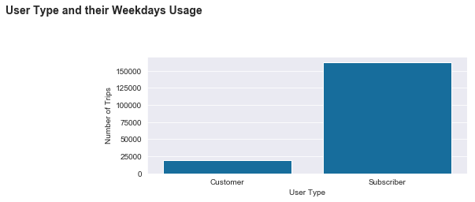

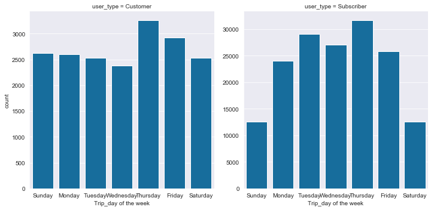

```python
#setting up base color and Style
base_color = sb.color_palette('colorblind')[0]
sb.set_style('darkgrid');
fig, ax = plt.subplots(figsize = [16,6]);
plt.suptitle('User Type and their Weekdays Usage', fontsize=14, fontweight='semibold', y=1.03);
#Exploring user_type variable in terms of number of trips
plt.subplot(2, 2, 2);
sb.countplot(data= fordgobike_df,x='user_type', color= base_color);
plt.xlabel('User Type');
plt.ylabel('Number of Trips');
plt.subplot(2, 2, 2);
weekday_order = ['Sunday','Monday','Tuesday','Wednesday','Thursday','Friday','Saturday']
sb.catplot(data=fordgobike_df, x='Trip_day of the week', col="user_type", order = weekday_order, kind='count',
           sharey = False, color = base_color);
```

## ( User Type and their Trips Duration)

> Most of trips are taking less than 15 mins and the top number of the trips takes about 10 mins.

> Subscribers have narrower trip duration than Customers.

> Subscibers have more specific Trips than casual Customers.

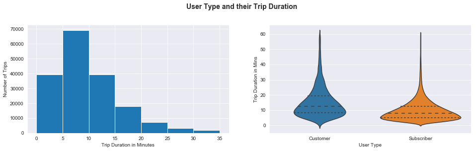

```python
fig, ax = plt.subplots(figsize = [16,4]);
plt.suptitle('User Type and their Trip Duration', fontsize=14, fontweight='semibold', y=1.03);
plt.subplot(1, 2, 1);
#Exploring trip duration variable in terms of number of trips
bins = np.arange(0, 40, 5);
plt.hist(data = fordgobike_df, x = 'duration_min', bins = bins);
plt.xlabel('Trip Duration in Minutes');
plt.ylabel('Number of Trips');
plt.subplot(1, 2, 2);
#Exploring User Type variable in terms of trip duration
sb.violinplot(data=fordgobike_df, x='user_type', y='duration_min', inner='quartile',scale="area");
plt.xlabel('User Type');
plt.ylabel('Trip Duration in Mins');
```

## (Trips Duration in Week days per User type)

> Subscribers rent bikes more efficiently as they have a shorter trip duration overall than customers.

> Both of Users type have a longer trip duration on weekend in relative to their trips during other week days.

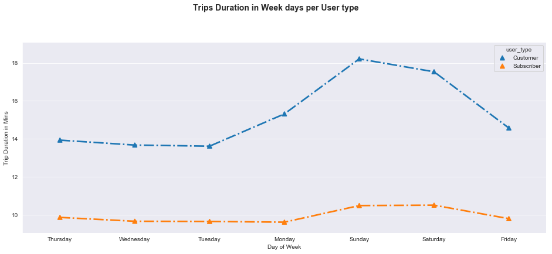

```python
plt.figure(figsize=[16, 6]);
plt.suptitle('Trips Duration in Week days per User type', fontsize=14, fontweight='semibold', y=1.03)
sb.pointplot(data=fordgobike_df, x='Trip_day of the week', y='duration_min', hue='user_type', errwidth=0, linestyles='-.'
             ,markers = '^');
plt.xlabel('Day of Week');
plt.ylabel('Trip Duration in Mins');
```